# R Notebook

CHOURI:305288-GUESMI:305466-DIALLO:293528

RBIG MINI PROJECT RENDERING

# INSTALL AND LOAD PACKAGES

```r
install.packages('dplyr')
install.packages('ggplot2')
install.packages('psych')
install.packages('ggcorrplot')
install.packages('ggworldcloud')
install.packages('rlang')
install.packages("GGally")
install.packages("installr")
install.packages('viridis')
install.packages("caret")
install.packages("ggpubr")
```

```r
# install pacman("package manager") if needed
if (!require("pacman")) install.packages("pacman")
```

#Loading Libraries

```r
library(GGally)
library(caret)
library(ggcorrplot)
library(ggplot2)
library(hrbrthemes)
library(viridis)
library(gridExtra)
library(grid)
library(Hmisc)
library(ggpubr)
library(rstatix)
library(plyr)
library(MASS)
library(ggpubr)
library(rstatix)
library(ggpubr)
library(factoextra)
library(gridExtra)
library(grid)
```

#Loading pacman libraries

```r
pacman::p_load(pacman, party, psych, rio, tidyverse)
```

# Import Data

```r
path <- "C:/Users/adnan/Desktop/RBIG/MP-5RBIG.xlsx"
students_dataset <- import(path) %>%
  as_tibble() %>%
  print()
```

| school | sex | age | address | famsize | Pstatus | Medu | Fedu | Mjob | Fjob | reason | guardian | traveltime | studytime | failures | schoolsup | famsup | paid | activities | nursery | higher | internet | romantic | famrel | freetime | goout | Dalc | Walc | health | absences | … |
| --- | --- | --- | --- | --- | --- | --- | --- | --- | --- | --- | --- | --- | --- | --- | --- | --- | --- | --- | --- | --- | --- | --- | --- | --- | --- | --- | --- | --- | --- | --- |
| GP | F | 18 | U | GT3 | A | 4 | 4 | at_home | teacher | course | mother | 2 | 2 | 0 | yes | no | no | no | yes | yes | no | no | 4 | 3 | 4 | 1 | 1 | 3 | 6 | … |
| GP | F | 17 | U | GT3 | T | 1 | 1 | at_home | other | course | father | 1 | 2 | 0 | no | yes | no | no | no | yes | yes | no | 5 | 3 | 3 | 1 | 1 | 3 | 4 | … |
| GP | F | 15 | U | LE3 | T | 1 | 1 | at_home | other | other | mother | 1 | 2 | 3 | yes | no | yes | no | yes | yes | yes | no | 4 | 3 | 2 | 2 | 3 | 3 | 10 | … |
| GP | F | 15 | U | GT3 | T | 4 | 2 | health | services | home | mother | 1 | 3 | 0 | no | yes | yes | yes | yes | yes | yes | yes | 3 | 2 | 2 | 1 | 1 | 5 | 2 | … |
| GP | F | 16 | U | GT3 | T | 3 | 3 | other | other | home | father | 1 | 2 | 0 | no | yes | yes | no | yes | yes | no | no | 4 | 3 | 2 | 1 | 2 | 5 | 4 | … |
| GP | M | 16 | U | LE3 | T | 4 | 3 | services | other | reputation | mother | 1 | 2 | 0 | no | yes | yes | yes | yes | yes | yes | no | 5 | 4 | 2 | 1 | 2 | 5 | 10 | … |
| GP | M | 16 | U | LE3 | T | 2 | 2 | other | other | home | mother | 1 | 2 | 0 | no | no | no | no | yes | yes | yes | no | 4 | 4 | 4 | 1 | 1 | 3 | 0 | … |
| GP | F | 17 | U | GT3 | A | 4 | 4 | other | teacher | home | mother | 2 | 2 | 0 | yes | yes | no | no | yes | yes | no | no | 4 | 1 | 4 | 1 | 1 | 1 | 6 | … |
| GP | M | 15 | U | LE3 | A | 3 | 2 | services | other | home | mother | 1 | 2 | 0 | no | yes | yes | no | yes | yes | yes | no | 4 | 2 | 2 | 1 | 1 | 1 | 0 | … |
| GP | M | 15 | U | GT3 | T | 3 | 4 | other | other | home | mother | 1 | 2 | 0 | no | yes | yes | yes | yes | yes | yes | no | 5 | 5 | 1 | 1 | 1 | 5 | 0 | … |

[output cut: 385 more lines]

```r
NA
```

#show all variables and their data type

```r
glimpse(students_dataset)
```

```
Rows: 395
Columns: 33
$ school     <chr> "GP", "GP", "GP", "GP", "GP", "GP", "GP", "GP", "GP", "GP", "GP", "GP", "GP", "GP", "GP", "GP", "...
$ sex        <chr> "F", "F", "F", "F", "F", "M", "M", "F", "M", "M", "F", "F", "M", "M", "M", "F", "F", "F", "M", "M...
$ age        <dbl> 18, 17, 15, 15, 16, 16, 16, 17, 15, 15, 15, 15, 15, 15, 15, 16, 16, 16, 17, 16, 15, 15, 16, 16, 1...
$ address    <chr> "U", "U", "U", "U", "U", "U", "U", "U", "U", "U", "U", "U", "U", "U", "U", "U", "U", "U", "U", "U...
$ famsize    <chr> "GT3", "GT3", "LE3", "GT3", "GT3", "LE3", "LE3", "GT3", "LE3", "GT3", "GT3", "GT3", "LE3", "GT3",...
$ Pstatus    <chr> "A", "T", "T", "T", "T", "T", "T", "A", "A", "T", "T", "T", "T", "T", "A", "T", "T", "T", "T", "T...
$ Medu       <dbl> 4, 1, 1, 4, 3, 4, 2, 4, 3, 3, 4, 2, 4, 4, 2, 4, 4, 3, 3, 4, 4, 4, 4, 2, 2, 2, 2, 4, 3, 4, 4, 4, 4...
$ Fedu       <dbl> 4, 1, 1, 2, 3, 3, 2, 4, 2, 4, 4, 1, 4, 3, 2, 4, 4, 3, 2, 3, 3, 4, 2, 2, 4, 2, 2, 2, 4, 4, 4, 4, 3...
$ Mjob       <chr> "at_home", "at_home", "at_home", "health", "other", "services", "other", "other", "services", "ot...
$ Fjob       <chr> "teacher", "other", "other", "services", "other", "other", "other", "teacher", "other", "other", ...
$ reason     <chr> "course", "course", "other", "home", "home", "reputation", "home", "home", "home", "home", "reput...
$ guardian   <chr> "mother", "father", "mother", "mother", "father", "mother", "mother", "mother", "mother", "mother...
$ traveltime <dbl> 2, 1, 1, 1, 1, 1, 1, 2, 1, 1, 1, 3, 1, 2, 1, 1, 1, 3, 1, 1, 1, 1, 1, 2, 1, 1, 1, 1, 1, 1, 1, 2, 1...
```

[output cut: 20 more lines]

#1 - Verification des valeurs NULL # Check fo missing values and impute them if needed.

#Missing data

```r
sum(is.na(students_dataset))
```

```
[1] 0
```

# check for extra charachters using the Unique function

```r
unique(students_dataset$schoolsup)
```

```
[1] "yes" "no"
```

```r
unique(students_dataset$famsup)
```

```
[1] "no"  "yes"
```

```r
unique(students_dataset$paid)
```

```
[1] "no"  "yes"
```

```r
unique(students_dataset$activities)
```

```
[1] "no"  "yes"
```

```r
unique(students_dataset$nursery)
```

```
[1] "yes" "no"
```

```r
unique(students_dataset$higher)
```

```
[1] "yes" "no"
```

```r
unique(students_dataset$internet)
```

```
[1] "no"  "yes"
```

```r
unique(students_dataset$romantic)
```

```
[1] "no"  "yes"
```

```r
unique(students_dataset$guardian)
```

```
[1] "mother" "father" "other"
```

```r
unique(students_dataset$reason)
```

```
[1] "course"     "other"      "home"       "reputation"
```

```r
unique(students_dataset$Fjob)
```

```
[1] "teacher"  "other"    "services" "health"   "at_home"
```

```r
unique(students_dataset$Mjob)
```

```
[1] "at_home"  "health"   "other"    "services" "teacher"
```

```r
unique(students_dataset$famsize)
```

```
[1] "GT3" "LE3"
```

```r
unique(students_dataset$address)
```

```
[1] "U" "R"
```

# 2- Add a binary categorical variable called finalResult, with level “pass” if the variable G3 is greater or equal to 10 and “fail” otherwise

```r
finalResult <- students_dataset$G3

students_dataset_finalresult <- students_dataset %>%
mutate(students_dataset, finalResult = ifelse(finalResult >= 10 , "pass", "fail"))

students_dataset_finalresult
```

| school | sex | age | address | famsize | Pstatus | Medu | Fedu | Mjob | Fjob | reason | guardian | traveltime | studytime | failures | schoolsup | famsup | paid | activities | nursery | higher | internet | romantic | famrel | freetime | goout | Dalc | Walc | health | absences | … |
| --- | --- | --- | --- | --- | --- | --- | --- | --- | --- | --- | --- | --- | --- | --- | --- | --- | --- | --- | --- | --- | --- | --- | --- | --- | --- | --- | --- | --- | --- | --- |
| GP | F | 18 | U | GT3 | A | 4 | 4 | at_home | teacher | course | mother | 2 | 2 | 0 | yes | no | no | no | yes | yes | no | no | 4 | 3 | 4 | 1 | 1 | 3 | 6 | … |
| GP | F | 17 | U | GT3 | T | 1 | 1 | at_home | other | course | father | 1 | 2 | 0 | no | yes | no | no | no | yes | yes | no | 5 | 3 | 3 | 1 | 1 | 3 | 4 | … |
| GP | F | 15 | U | LE3 | T | 1 | 1 | at_home | other | other | mother | 1 | 2 | 3 | yes | no | yes | no | yes | yes | yes | no | 4 | 3 | 2 | 2 | 3 | 3 | 10 | … |
| GP | F | 15 | U | GT3 | T | 4 | 2 | health | services | home | mother | 1 | 3 | 0 | no | yes | yes | yes | yes | yes | yes | yes | 3 | 2 | 2 | 1 | 1 | 5 | 2 | … |
| GP | F | 16 | U | GT3 | T | 3 | 3 | other | other | home | father | 1 | 2 | 0 | no | yes | yes | no | yes | yes | no | no | 4 | 3 | 2 | 1 | 2 | 5 | 4 | … |
| GP | M | 16 | U | LE3 | T | 4 | 3 | services | other | reputation | mother | 1 | 2 | 0 | no | yes | yes | yes | yes | yes | yes | no | 5 | 4 | 2 | 1 | 2 | 5 | 10 | … |
| GP | M | 16 | U | LE3 | T | 2 | 2 | other | other | home | mother | 1 | 2 | 0 | no | no | no | no | yes | yes | yes | no | 4 | 4 | 4 | 1 | 1 | 3 | 0 | … |
| GP | F | 17 | U | GT3 | A | 4 | 4 | other | teacher | home | mother | 2 | 2 | 0 | yes | yes | no | no | yes | yes | no | no | 4 | 1 | 4 | 1 | 1 | 1 | 6 | … |
| GP | M | 15 | U | LE3 | A | 3 | 2 | services | other | home | mother | 1 | 2 | 0 | no | yes | yes | no | yes | yes | yes | no | 4 | 2 | 2 | 1 | 1 | 1 | 0 | … |
| GP | M | 15 | U | GT3 | T | 3 | 4 | other | other | home | mother | 1 | 2 | 0 | no | yes | yes | yes | yes | yes | yes | no | 5 | 5 | 1 | 1 | 1 | 5 | 0 | … |

[output cut: 385 more lines]

```r
NA
```

3 - Adding a categorical variable called academicGrade, with five levels “A”, “B”, “C”, “D”, “E” depending on whether the variable G3 is between 16 and 20, 14 and 15, 12 and 13, 10 and 11, 0 and 9 (Note: don’t forget this variable in the following study).

```r
academicGrade <- students_dataset$G3

students_dataset_academic_Grade <- students_dataset_finalresult %>% mutate(students_dataset_finalresult, academicGrade = ifelse(academicGrade %in% 16:20 , "A",
ifelse(academicGrade %in% 14:15 , "B",
ifelse(academicGrade %in% 12:13 , "C",
ifelse(academicGrade %in% 10:11 , "D", "E")))))

students_dataset_academic_Grade
```

| school | sex | age | address | famsize | Pstatus | Medu | Fedu | Mjob | Fjob | reason | guardian | traveltime | studytime | failures | schoolsup | famsup | paid | activities | nursery | higher | internet | romantic | famrel | freetime | goout | Dalc | Walc | health | absences | … |
| --- | --- | --- | --- | --- | --- | --- | --- | --- | --- | --- | --- | --- | --- | --- | --- | --- | --- | --- | --- | --- | --- | --- | --- | --- | --- | --- | --- | --- | --- | --- |
| GP | F | 18 | U | GT3 | A | 4 | 4 | at_home | teacher | course | mother | 2 | 2 | 0 | yes | no | no | no | yes | yes | no | no | 4 | 3 | 4 | 1 | 1 | 3 | 6 | … |
| GP | F | 17 | U | GT3 | T | 1 | 1 | at_home | other | course | father | 1 | 2 | 0 | no | yes | no | no | no | yes | yes | no | 5 | 3 | 3 | 1 | 1 | 3 | 4 | … |
| GP | F | 15 | U | LE3 | T | 1 | 1 | at_home | other | other | mother | 1 | 2 | 3 | yes | no | yes | no | yes | yes | yes | no | 4 | 3 | 2 | 2 | 3 | 3 | 10 | … |
| GP | F | 15 | U | GT3 | T | 4 | 2 | health | services | home | mother | 1 | 3 | 0 | no | yes | yes | yes | yes | yes | yes | yes | 3 | 2 | 2 | 1 | 1 | 5 | 2 | … |
| GP | F | 16 | U | GT3 | T | 3 | 3 | other | other | home | father | 1 | 2 | 0 | no | yes | yes | no | yes | yes | no | no | 4 | 3 | 2 | 1 | 2 | 5 | 4 | … |
| GP | M | 16 | U | LE3 | T | 4 | 3 | services | other | reputation | mother | 1 | 2 | 0 | no | yes | yes | yes | yes | yes | yes | no | 5 | 4 | 2 | 1 | 2 | 5 | 10 | … |
| GP | M | 16 | U | LE3 | T | 2 | 2 | other | other | home | mother | 1 | 2 | 0 | no | no | no | no | yes | yes | yes | no | 4 | 4 | 4 | 1 | 1 | 3 | 0 | … |
| GP | F | 17 | U | GT3 | A | 4 | 4 | other | teacher | home | mother | 2 | 2 | 0 | yes | yes | no | no | yes | yes | no | no | 4 | 1 | 4 | 1 | 1 | 1 | 6 | … |
| GP | M | 15 | U | LE3 | A | 3 | 2 | services | other | home | mother | 1 | 2 | 0 | no | yes | yes | no | yes | yes | yes | no | 4 | 2 | 2 | 1 | 1 | 1 | 0 | … |
| GP | M | 15 | U | GT3 | T | 3 | 4 | other | other | home | mother | 1 | 2 | 0 | no | yes | yes | yes | yes | yes | yes | no | 5 | 5 | 1 | 1 | 1 | 5 | 0 | … |

[output cut: 385 more lines]

# data summary

```r
summary(students_dataset)
```

```
    school              sex                 age         address            famsize            Pstatus               Medu            Fedu
 Length:395         Length:395         Min.   :15.0   Length:395         Length:395         Length:395         Min.   :0.000   Min.   :0.000
 Class :character   Class :character   1st Qu.:16.0   Class :character   Class :character   Class :character   1st Qu.:2.000   1st Qu.:2.000
 Mode  :character   Mode  :character   Median :17.0   Mode  :character   Mode  :character   Mode  :character   Median :3.000   Median :2.000
                                       Mean   :16.7                                                            Mean   :2.749   Mean   :2.522
                                       3rd Qu.:18.0                                                            3rd Qu.:4.000   3rd Qu.:3.000
                                       Max.   :22.0                                                            Max.   :4.000   Max.   :4.000
     Mjob               Fjob              reason            guardian           traveltime      studytime        failures       schoolsup
 Length:395         Length:395         Length:395         Length:395         Min.   :1.000   Min.   :1.000   Min.   :0.0000   Length:395
 Class :character   Class :character   Class :character   Class :character   1st Qu.:1.000   1st Qu.:1.000   1st Qu.:0.0000   Class :character
 Mode  :character   Mode  :character   Mode  :character   Mode  :character   Median :1.000   Median :2.000   Median :0.0000   Mode  :character
                                                                             Mean   :1.448   Mean   :2.035   Mean   :0.3342
                                                                             3rd Qu.:2.000   3rd Qu.:2.000   3rd Qu.:0.0000
                                                                             Max.   :4.000   Max.   :4.000   Max.   :3.0000
    famsup              paid            activities          nursery             higher            internet           romantic
 Length:395         Length:395         Length:395         Length:395         Length:395         Length:395         Length:395
 Class :character   Class :character   Class :character   Class :character   Class :character   Class :character   Class :character
 Mode  :character   Mode  :character   Mode  :character   Mode  :character   Mode  :character   Mode  :character   Mode  :character



     famrel         freetime         goout            Dalc            Walc           health         absences            G1              G2
 Min.   :1.000   Min.   :1.000   Min.   :1.000   Min.   :1.000   Min.   :1.000   Min.   :1.000   Min.   : 0.000   Min.   : 3.00   Min.   : 0.00
 1st Qu.:4.000   1st Qu.:3.000   1st Qu.:2.000   1st Qu.:1.000   1st Qu.:1.000   1st Qu.:3.000   1st Qu.: 0.000   1st Qu.: 8.00   1st Qu.: 9.00
 Median :4.000   Median :3.000   Median :3.000   Median :1.000   Median :2.000   Median :4.000   Median : 4.000   Median :11.00   Median :11.00
 Mean   :3.944   Mean   :3.235   Mean   :3.109   Mean   :1.481   Mean   :2.291   Mean   :3.554   Mean   : 5.709   Mean   :10.91   Mean   :10.71
 3rd Qu.:5.000   3rd Qu.:4.000   3rd Qu.:4.000   3rd Qu.:2.000   3rd Qu.:3.000   3rd Qu.:5.000   3rd Qu.: 8.000   3rd Qu.:13.00   3rd Qu.:13.00
 Max.   :5.000   Max.   :5.000   Max.   :5.000   Max.   :5.000   Max.   :5.000   Max.   :5.000   Max.   :75.000   Max.   :19.00   Max.   :19.00
       G3
 Min.   : 0.00
 1st Qu.: 8.00
 Median :11.00
 Mean   :10.42
 3rd Qu.:14.00
 Max.   :20.00
```

Study of categorical variables. 2.1 Study individually the main categorical variables (frequencies, proportions, charts, Chi-squared test of goodness of fit, etc.).

```r
df_categorial <- students_dataset[c(1,2,4,5,6,9,10,11,12,16,17,18,19,20,21,22,23)] #les nombres
df_categorial
```

| school | sex | address | famsize | Pstatus | Mjob | Fjob | reason | guardian | schoolsup | famsup | paid | activities | nursery | higher | internet | romantic |
| --- | --- | --- | --- | --- | --- | --- | --- | --- | --- | --- | --- | --- | --- | --- | --- | --- |
| GP | F | U | GT3 | A | at_home | teacher | course | mother | yes | no | no | no | yes | yes | no | no |
| GP | F | U | GT3 | T | at_home | other | course | father | no | yes | no | no | no | yes | yes | no |
| GP | F | U | LE3 | T | at_home | other | other | mother | yes | no | yes | no | yes | yes | yes | no |
| GP | F | U | GT3 | T | health | services | home | mother | no | yes | yes | yes | yes | yes | yes | yes |
| GP | F | U | GT3 | T | other | other | home | father | no | yes | yes | no | yes | yes | no | no |
| GP | M | U | LE3 | T | services | other | reputation | mother | no | yes | yes | yes | yes | yes | yes | no |
| GP | M | U | LE3 | T | other | other | home | mother | no | no | no | no | yes | yes | yes | no |
| GP | F | U | GT3 | A | other | teacher | home | mother | yes | yes | no | no | yes | yes | no | no |
| GP | M | U | LE3 | A | services | other | home | mother | no | yes | yes | no | yes | yes | yes | no |
| GP | M | U | GT3 | T | other | other | home | mother | no | yes | yes | yes | yes | yes | yes | no |

[output cut: 385 more lines]

# SUmmary of categorical data

```r
df_categorial %>% summary()
```

```
    school              sex              address            famsize            Pstatus              Mjob               Fjob
 Length:395         Length:395         Length:395         Length:395         Length:395         Length:395         Length:395
 Class :character   Class :character   Class :character   Class :character   Class :character   Class :character   Class :character
 Mode  :character   Mode  :character   Mode  :character   Mode  :character   Mode  :character   Mode  :character   Mode  :character
    reason            guardian          schoolsup            famsup              paid            activities          nursery
 Length:395         Length:395         Length:395         Length:395         Length:395         Length:395         Length:395
 Class :character   Class :character   Class :character   Class :character   Class :character   Class :character   Class :character
 Mode  :character   Mode  :character   Mode  :character   Mode  :character   Mode  :character   Mode  :character   Mode  :character
    higher            internet           romantic
 Length:395         Length:395         Length:395
 Class :character   Class :character   Class :character
 Mode  :character   Mode  :character   Mode  :character
```

#Frequence sur le SEX

```r
students_dataset%>% select(sex)%>%
  summary()
```

```
     sex
 Length:395
 Class :character
 Mode  :character
```

```r
sex_study <- df_categorial %>%
  select(sex)%>%
  table() %>% print() # put the data in the right format
```

```
.
  F   M
208 187
```

```r
mean(sex_study)
```

```
[1] 197.5
```

# Proportions

```r
df_sex <- table(df_categorial$sex) #pour les effectifs
(tableSexprop <- round(prop.table(df_sex),2)) #prop : propotion
```

```
   F    M
0.53 0.47
```

#Chi-squared test of goodness of fit,

```r
tchi <- chisq.test(tableSexprop)
```

```
Chi-squared approximation may be incorrect
```

```r
tchi
```

```
    Chi-squared test for given probabilities

data:  tableSexprop
X-squared = 0.0036, df = 1, p-value = 0.9522
```

```r
#Additional tables
tchi$observed #Obsered frequencies (same as ct)
```

```
   F    M
0.53 0.47
```

```r
tchi$residuals #Pearson's residual
```

```
          F           M
 0.04242641 -0.04242641
```

```r
tchi$stdres #Standardized residual
```

```
    F     M
 0.06 -0.06
```

2 - 2 Represent associations between pairs of categorical variables (Stacked bar charts, Grouped bar charts, Segmented bar charts, etc.).

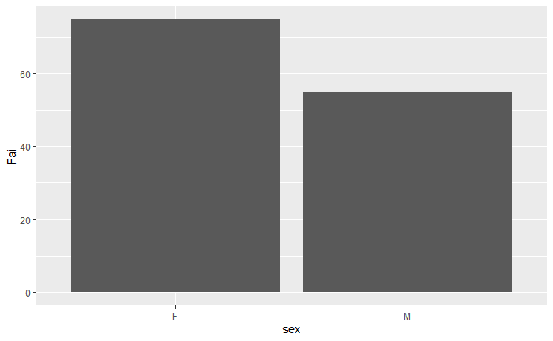

```r
finalResult_by_sex %>% ggplot()+aes(x=sex,y=Fail)+geom_bar(stat="identity")
```

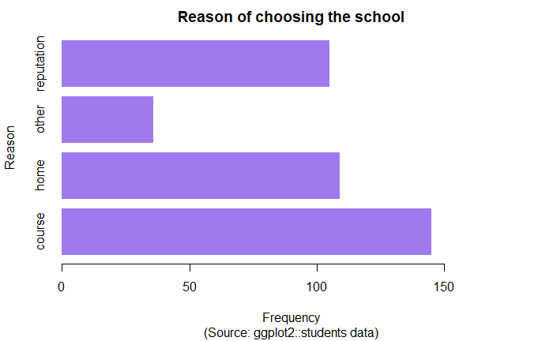

```r
#CHARTS
students_dataset %>%
  select(reason )%>%
  table() %>% #Put data in appropriate format
  barplot(
    main="Reason of choosing the school",
    sub = "(Source: ggplot2::students data)",
    horiz = T, #Draw horizontal bars
    ylab="Reason", # Flip axis lables
    xlab = "Frequency",
    xlim = c(0,180), #Limites for X axis
    border = NA, #No borders on bars
    col = "#9F79EE",
    )
```

```r
#Stacked bars : step1 : create table
df_reason <- students_dataset %>%
  select(Pstatus , reason)%>%
  table() %>%
  print()
```

[output not shown]

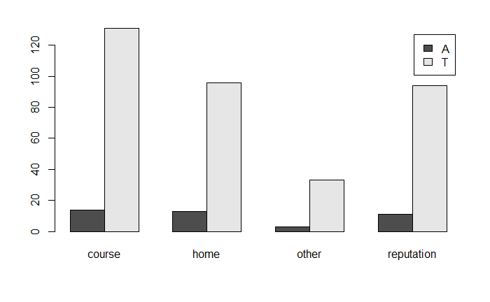

```r
#And now we'll create a graph

#sIDE BY SIDE bar
df_reason %>%
  barplot(
    legend = rownames(.), #Dot is placeholder for pipe
    beside = T #Put bars next to each other
  )
```

```r
#this is a really good way of looking at the association btw categorical variables and the frequencies and the various combinations that they present.
```

```r
#Compare mean final grade in Math  of two schools
aggregate(students_dataset[,33], students_dataset["school"], mean)
```

| school | G3 |
| --- | --- |
| GP | 10.489971 |
| MS | 9.847826 |

```r
NA
```

# 2-3 Study associations between pairs of categorical variables with Chi-squared tests.

```r
chisq.test(students_dataset$Mjob, students_dataset$Fjob, correct=FALSE)
```

```
Chi-squared approximation may be incorrect
```

```
    Pearson's Chi-squared test

data:  students_dataset$Mjob and students_dataset$Fjob
X-squared = 73.381, df = 16, p-value = 2.534e-09
```

# 3 - STUDY OF QUANTITATIVE VARIABLES

# 3-1 Study individually the main quantitative variables (descriptives statistics, charts, outliers, confidence intervals, relevant statistical tests, etc.).

```r
df_quantitative <- students_dataset[c(3,7,8,13,14,15,24,25,26,27,28,29,30,31,32,33)]
```

[output not shown]

[output cut: 6 more lines]

Historgram of Age

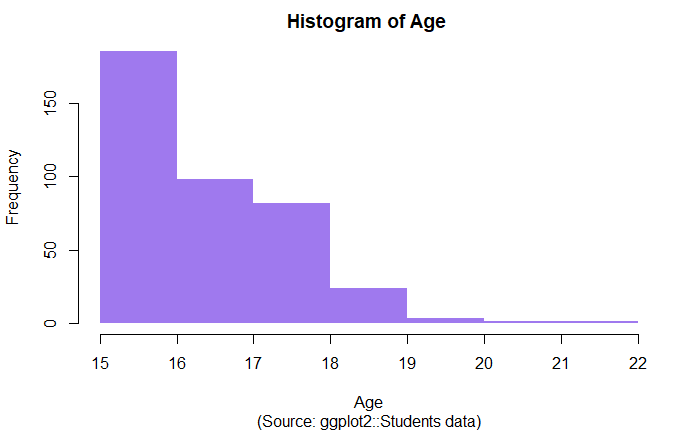

```r
#Histogram  with options
hist(students_dataset$age,
     breaks = 8, #suggest number of breaks/ THIS has to do with the number of bars in your histogram,
     main   = "Histogram of Age ",
     sub    =  "(Source: ggplot2::Students data)",
     ylab   =  "Frequency",
     xlab   =  "Age",
     border = NA, #No borders on bars
     col    = "#9F79EE")
```

Final Grade in Math(G3)- Density

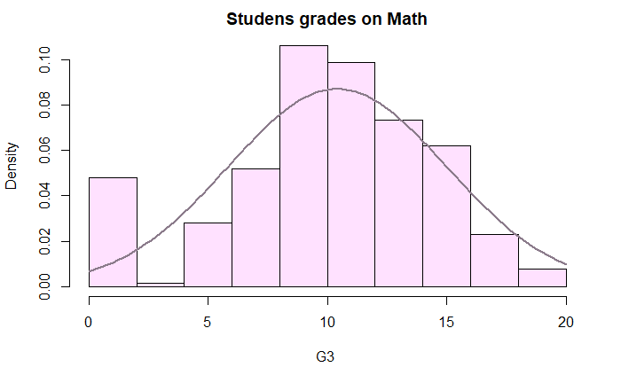

```r
h <- hist(students_dataset$G3, #sAVE histogram as object
          breaks = 11,#"Suggest" 11 bins
          freq = FALSE,
          col = "thistle1",#Or use:col = colors() [626]
          main = "Studens grades on Math",
          xlab = "G3 ")


curve(dnorm(x, mean = mean(students_dataset$G3), sd = sd(students_dataset$G3)),
      col = "thistle4",
      lwd = 2,
      add = TRUE)
```

```r
NA
NA
```

#BOX PLOT OF FREQUENCIES

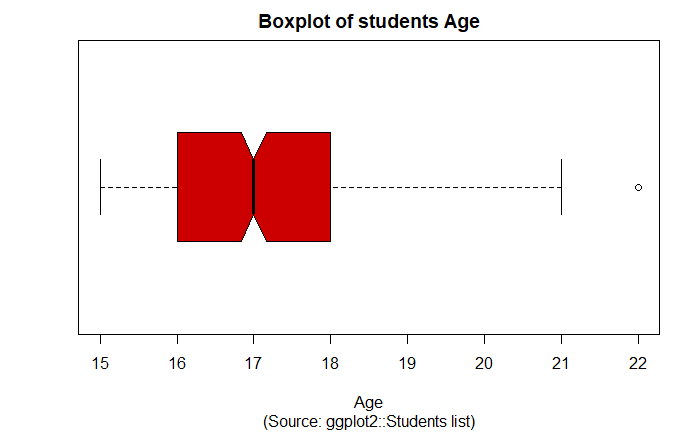

```r
#Boxplot with options
students_dataset %>%
  select(age) %>%
  boxplot(
    horizontal = T, #Horizontal
    notch = T, #confidence interval for the median
    main = "Boxplot of students Age",
    sub  = "(Source: ggplot2::Students list)",
    xlab = "Age",
    col  = "#CD0000"

  )
```

```r
#Identify outlier

students_dataset%>%
    select(age, absences) %>%
  filter(age > 21)%>%  #Select outlier / but this outlier is a true data
  print()
```

| age | absences |
| --- | --- |
| 22 | 16 |

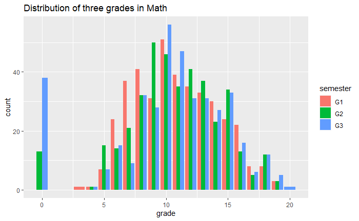

```r
mathGrades <- students_dataset %>%
gather(G1, G2, G3 , key="semester", value="grade") %>%
ggplot() +
geom_bar(aes(x=grade, fill=semester), position="dodge") +
ggtitle("Distribution of three grades in Math")

mathGrades
```

For all students in math as well as the subset of math students the mean grade slightly decreases as the semester progresses.

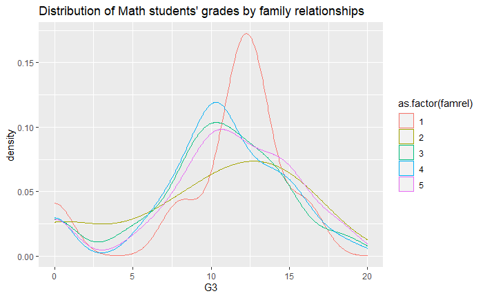

```r
famMath <- ggplot(students_dataset, aes(x=G3)) +
geom_density(aes(color=as.factor(famrel))) +
ggtitle("Distribution of Math students' grades by family relationships")

famMath
```

#relation between the mean of the final grade in math and Goout

```r
students_dataset$goout <- as.factor(students_dataset$goout)
students_dataset%>%
group_by(goout)%>%
summarise(AverageScore= mean(G3,na.rm=TRUE))%>%
arrange(desc(AverageScore))
```

| goout | AverageScore |
| --- | --- |
| 2 | 11.194175 |
| 3 | 10.961538 |
| 1 | 9.869565 |
| 4 | 9.651163 |
| 5 | 9.037736 |

#BOXPLOTS BY GROUP

Absences in function of health

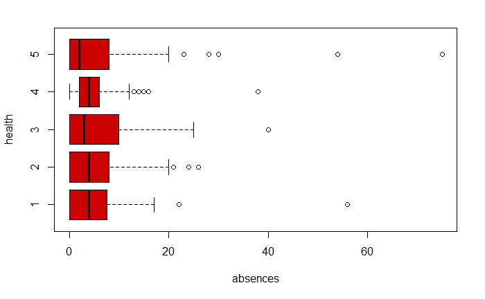

```r
#Boxplot by group using boxplot()
students_dataset %>%
  select(absences, health)%>%
  boxplot(
    absences ~ health, #tidle indicates formula/it says price is a funtion of color
    data = . , #Dot is placeholder for pipe/dot means take the thing from before
    col = "#CD0000",
    horizontal = T
  )
```

Linear regression

```r
reg <- lm(G3~absences,data=students_dataset)
summary(reg)
```

```
Call:
lm(formula = G3 ~ absences, data = students_dataset)

Residuals:
     Min       1Q   Median       3Q      Max
-10.3033  -2.3033   0.5007   3.4811   9.6183

Coefficients:
            Estimate Std. Error t value Pr(>|t|)
(Intercept) 10.30327    0.28347  36.347   <2e-16 ***
absences     0.01961    0.02886   0.679    0.497
---
Signif. codes:  0 ‘***’ 0.001 ‘**’ 0.01 ‘*’ 0.05 ‘.’ 0.1 ‘ ’ 1

Residual standard error: 4.585 on 393 degrees of freedom
Multiple R-squared:  0.001173,  Adjusted R-squared:  -0.001369
F-statistic: 0.4615 on 1 and 393 DF,  p-value: 0.4973
```

```r
reg <- lm(absences  ~ age + Medu + traveltime + studytime +failures+famrel +freetime +goout+ Dalc + Walc + health + G3 , data = students_dataset)

summary(reg)
```

```
Call:
lm(formula = absences ~ age + Medu + traveltime + studytime +
    failures + famrel + freetime + goout + Dalc + Walc + health +
    G3, data = students_dataset)

Residuals:
    Min      1Q  Median      3Q     Max
-10.429  -4.353  -1.761   2.191  65.863

Coefficients:
             Estimate Std. Error t value Pr(>|t|)
(Intercept) -12.72253    6.43952  -1.976 0.048914 *
age           1.13533    0.33015   3.439 0.000649 ***
Medu          0.96901    0.38780   2.499 0.012886 *
traveltime   -0.34022    0.58767  -0.579 0.562982
studytime    -0.42915    0.50103  -0.857 0.392247
failures      0.62370    0.60372   1.033 0.302217
famrel       -0.17030    0.45690  -0.373 0.709567
freetime     -0.78229    0.42996  -1.819 0.069631 .
goout2       -1.80167    1.83741  -0.981 0.327441
goout3       -1.85498    1.81477  -1.022 0.307358
goout4       -1.55029    1.91771  -0.808 0.419364
goout5       -1.47246    2.10676  -0.699 0.485030
Dalc          0.26317    0.59716   0.441 0.659687
Walc          0.64507    0.44310   1.456 0.146273
health       -0.09557    0.29121  -0.328 0.742951
G3            0.12092    0.09544   1.267 0.205944
---
Signif. codes:  0 ‘***’ 0.001 ‘**’ 0.01 ‘*’ 0.05 ‘.’ 0.1 ‘ ’ 1

Residual standard error: 7.819 on 379 degrees of freedom
Multiple R-squared:  0.08173,   Adjusted R-squared:  0.04538
F-statistic: 2.249 on 15 and 379 DF,  p-value: 0.004904
```

[figure not shown]

```r
#install.packages("GGally")

ggpairs(df_quantitative)
```

t.test

```r
t.test(students_dataset$G3~students_dataset$sex)
```

```
    Welch Two Sample t-test

data:  students_dataset$G3 by students_dataset$sex
t = -2.0651, df = 390.57, p-value = 0.03958
alternative hypothesis: true difference in means is not equal to 0
95 percent confidence interval:
 -1.85073226 -0.04545244
sample estimates:
mean in group F mean in group M
       9.966346       10.914439
```

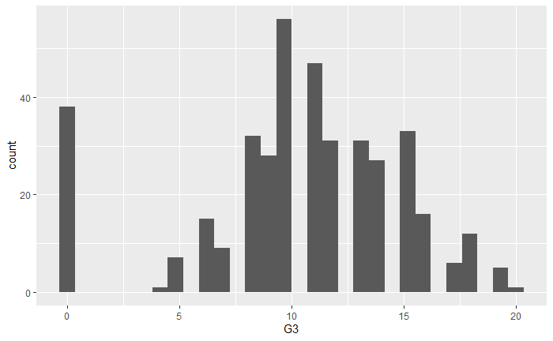

```r
#G3
ggplot(data=students_dataset)+geom_histogram(mapping = aes(x=G3))
```

```r
NA
NA
```

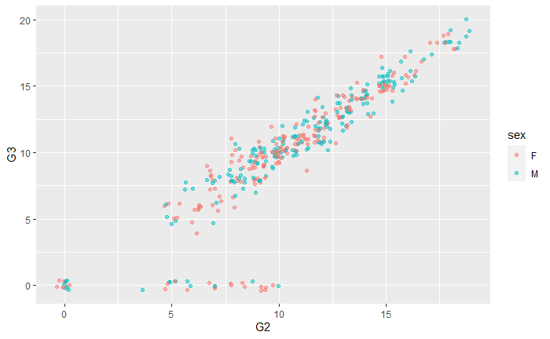

```r
ggplot(students_dataset,
       aes(G2,G3,
          color = sex))+geom_jitter(alpha = .5)
```

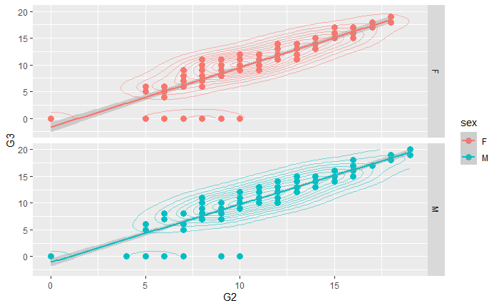

```r
#Scatterplot, colored by species ,fit line,
ggplot(students_dataset,
       aes(G2,G3,
          color = sex))+geom_point(size = 3)+
  geom_smooth(method = lm)+
  geom_density2d(alpha = .5)+facet_grid(sex ~ .)
```

```r
  theme(legend.position = "bottom")
```

```
List of 1
 $ legend.position: chr "bottom"
 - attr(*, "class")= chr [1:2] "theme" "gg"
 - attr(*, "complete")= logi FALSE
 - attr(*, "validate")= logi TRUE
```

```r
   #this is going to make it look like maps with circles drawn around them as a way of indicating something akin to confidence intervals, but really a map to indicate how bunched up the data are and this is as elaborate as we're going to get in this one
```

Correlation between grade OF Math in the first class and second class.

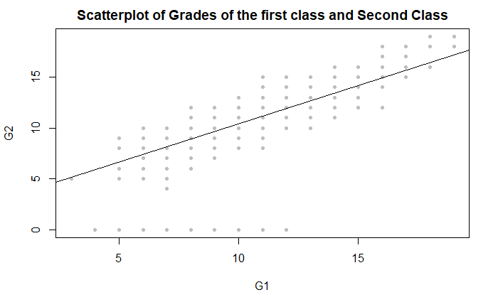

```r
#Bivariate scatterplot with options

df_quantitative %>%
  select(G1,G2) %>%
  plot(
    main = "Scatterplot of Grades of the first class and Second Class", #I'm going to put a title on
    xlab = "G1" ,#I'm going to put a label, By the way, you have to use the escape                                                 character if you want to include the quotes in your labels
    ylab = "G2",
    col = "gray", # Color of points ,
    pch = 20,     #"Pch = Plotting charachter"(small circle)
  )


#Add fit linear regression line (y ~ x)
students_dataset %>%
  lm(G1 ~ G2, data = .) %>%
  abline()
```

# Relation between the access to the internet and student preformance (Inetrnet,G3)

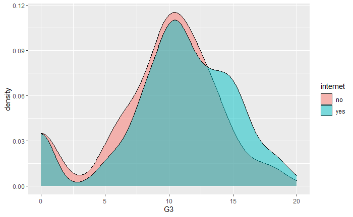

```r
students_dataset%>%
group_by(internet)%>%
ggplot(aes(x=G3, fill=internet))+
geom_density( alpha=0.5)
```

# Relation between health and absences

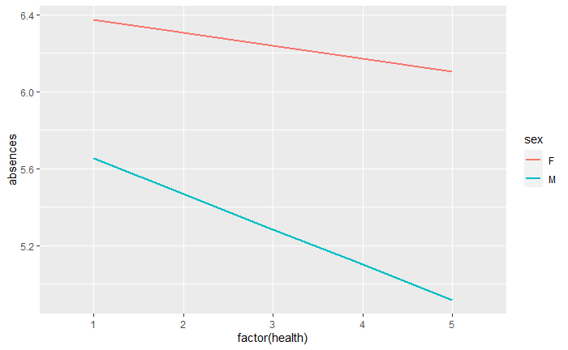

```r
students_dataset%>%
group_by(sex)%>%
ggplot(aes(x=factor(health), y=absences, color=sex))+
geom_smooth(aes(group=sex), method="lm", se=FALSE)
```

#Average final score for different levels of alcohol consumption on weekends and weekdays

```r
students_dataset %>%
   group_by(Walc)%>%
  aggregate(G3~Walc, data=., mean)%>%
  arrange(desc(G3))
```

| Walc | G3 |
| --- | --- |
| 1 | 10.735099 |
| 3 | 10.725000 |
| 5 | 10.142857 |
| 2 | 10.082353 |
| 4 | 9.686275 |

```r
students_dataset%>%
   group_by(Dalc)%>%
  aggregate(G3~Dalc, data=., mean)%>%
  arrange(desc(G3))
```

| Dalc | G3 |
| --- | --- |
| 1 | 10.731884 |
| 5 | 10.666667 |
| 3 | 10.500000 |
| 4 | 9.888889 |
| 2 | 9.253333 |

```r
NA
```

# 3-2 - Compute a correlation matrix for some quantitative variables Draw a heat map for this correlation matrix and a scatterplot matrix.

[output not shown]

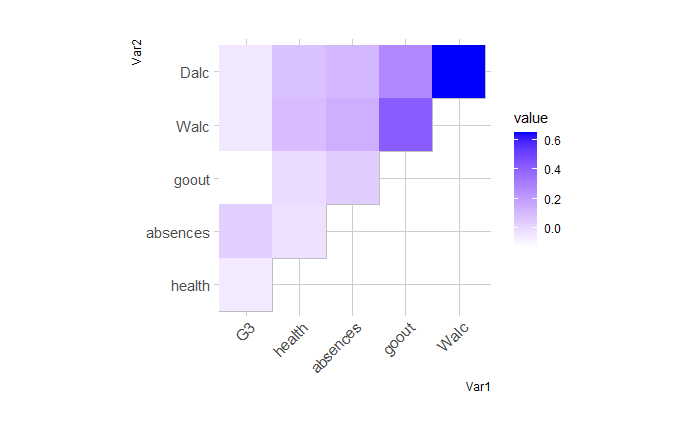

```r
d.quant <- students_dataset %>% select(G3,Walc,Dalc,health,absences,goout)

a <- cor(d.quant, use="complete.obs")



ggcorrplot(a, hc.order = TRUE , type = "upper", lab = TRUE) + geom_tile()+
   scale_fill_gradient(low="white", high="blue") +
   theme_ipsum()+theme(axis.text.x = element_text(angle = 45 , hjust = 1))
```

[output not shown]

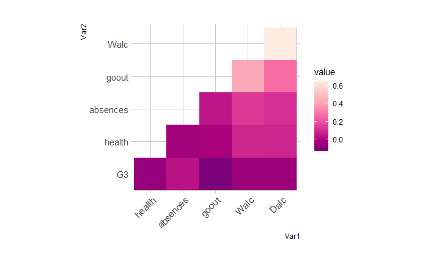

```r
ggcorrplot(a, hc.order = TRUE ,type = "lower",  lab = TRUE) + geom_tile()+
  scale_fill_distiller(palette = "RdPu") +
  theme_ipsum()+theme(axis.text.x = element_text(angle = 45 , hjust = 1))
```

[output not shown]

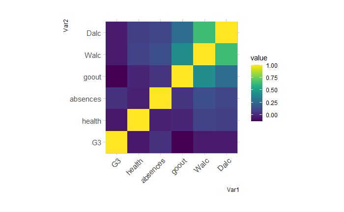

```r
ggcorrplot(a, hc.order = TRUE , lab = TRUE) + geom_tile()+
  scale_fill_viridis(discrete=FALSE) +
  theme_ipsum()+theme(axis.text.x = element_text(angle = 45 , hjust = 1))
```

```r
#BIVARIATE REGRESSION
```

```
There were 34 warnings (use warnings() to see them)
```

```r
#Compute and save bivariate regression
fit1 <- lm(students_dataset$G3  ~ students_dataset$age)

fit1 #gives us the inetrcep and the slope
```

```
Call:
lm(formula = students_dataset$G3 ~ students_dataset$age)

Coefficients:
         (Intercept)  students_dataset$age
             20.1011               -0.5801
```

```r
#Summarize regression model
summary(fit1)
```

```
Call:
lm(formula = students_dataset$G3 ~ students_dataset$age)

Residuals:
     Min       1Q   Median       3Q      Max
-11.3992  -1.6588   0.3412   3.1809   9.5014

Coefficients:
                     Estimate Std. Error t value Pr(>|t|)
(Intercept)           20.1011     2.9928   6.717 6.54e-11 ***
students_dataset$age  -0.5801     0.1787  -3.246  0.00127 **
---
Signif. codes:  0 ‘***’ 0.001 ‘**’ 0.01 ‘*’ 0.05 ‘.’ 0.1 ‘ ’ 1

Residual standard error: 4.527 on 393 degrees of freedom
Multiple R-squared:  0.02611,   Adjusted R-squared:  0.02363
F-statistic: 10.54 on 1 and 393 DF,  p-value: 0.001271
```

```r
#Confidence intervales for coefficients
confint(fit1)
```

```
                          2.5 %     97.5 %
(Intercept)          14.2172397 25.9849780
students_dataset$age -0.9315125 -0.2287416
```

```r
#Predict values of "G3"
predict(fit1)
```

[output not shown]

[output cut: 11 more lines]

```
 9.658822 10.238949 10.238949 10.238949  9.078695  9.658822  8.498568  9.078695  9.078695  9.078695  9.078695  9.078695
      313       314       315       316       317       318       319       320       321       322       323       324
 9.078695  9.078695  9.078695  9.078695  9.658822  9.658822 10.238949  9.658822 10.238949 10.238949 10.238949 10.238949
      325       326       327       328       329       330       331       332       333       334       335       336
10.238949  9.658822 10.238949 10.238949 10.238949 10.238949  9.658822 10.238949  9.658822  9.658822  9.658822 10.238949
      337       338       339       340       341       342       343       344       345       346       347       348
 9.078695 10.238949  9.658822 10.238949  9.078695  9.658822  9.658822 10.238949  9.658822  9.658822  9.658822  9.658822
      349       350       351       352       353       354       355       356       357       358       359       360
10.238949  9.658822  9.078695 10.238949  9.658822  9.078695 10.238949  9.658822 10.238949 10.238949  9.658822  9.658822
      361       362       363       364       365       366       367       368       369       370       371       372
 9.658822  9.658822  9.658822 10.238949 10.238949  9.658822  9.658822 10.238949  9.658822  9.658822  9.078695  9.658822
      373       374       375       376       377       378       379       380       381       382       383       384
10.238949 10.238949  9.658822  9.658822  8.498568  9.658822  9.658822 10.238949  9.658822  9.658822 10.238949  9.078695
      385       386       387       388       389       390       391       392       393       394       395
 9.658822  9.658822  9.658822  9.078695  9.658822  9.658822  8.498568 10.238949  7.918440  9.658822  9.078695
```

```r
#Predict intervals for values of "volunteering"
predict(fit1, interval = "prediction")
```

```
predictions on current data refer to _future_ responses
```

```
          fit        lwr      upr
1    9.658822  0.7356482 18.58200
2   10.238949  1.3269045 19.15099
3   11.399203  2.4678884 20.33052
4   11.399203  2.4678884 20.33052
5   10.819076  1.9043137 19.73384
6   10.819076  1.9043137 19.73384
7   10.819076  1.9043137 19.73384
8   10.238949  1.3269045 19.15099
9   11.399203  2.4678884 20.33052
10  11.399203  2.4678884 20.33052
11  11.399203  2.4678884 20.33052
12  11.399203  2.4678884 20.33052
13  11.399203  2.4678884 20.33052
14  11.399203  2.4678884 20.33052
```

[output cut: 320 more lines]

#Regression diagnostics

```r
lm.influence(fit1)
```

[output not shown]

[output cut: 618 more lines]

```
There were 34 warnings (use warnings() to see them)
```

```r
influence.measures(fit1)
```

```
Influence measures of
     lm(formula = students_dataset$G3 ~ students_dataset$age) :
```

|  | dfb.1_ | dfb.st_. | dffit | cov.r | cook.d | hat | inf |
| --- | --- | --- | --- | --- | --- | --- | --- |
| 1 | 0.0385706908 | -0.0418017525 | -0.058454530 | 1.0069701 | 1.709963e-03 | 0.005181327 |  |
| 2 | 0.0076319009 | -0.0112594211 | -0.048556593 | 1.0033010 | 1.179235e-03 | 0.002675506 |  |
| 3 | -0.0219508164 | 0.0208206060 | -0.026042519 | 1.0117150 | 3.398882e-04 | 0.007016298 |  |
| 4 | 0.0565285452 | -0.0536179861 | 0.067065647 | 1.0089311 | 2.250982e-03 | 0.007016298 |  |
| 5 | -0.0056633129 | 0.0049834685 | -0.010394894 | 1.0082549 | 5.416021e-05 | 0.003287163 |  |
| 6 | 0.0289383633 | -0.0254644984 | 0.053115770 | 1.0040364 | 1.411162e-03 | 0.003287163 |  |
| 7 | 0.0012509094 | -0.0011007457 | 0.002296018 | 1.0084152 | 2.642564e-06 | 0.003287163 |  |
| 8 | 0.0076319009 | -0.0112594211 | -0.048556593 | 1.0033010 | 1.179235e-03 | 0.002675506 |  |
| 9 | 0.1196603540 | -0.1134992448 | 0.141965428 | 0.9976394 | 1.002982e-02 | 0.007016298 |  |
| 10 | 0.0565285452 | -0.0536179861 | 0.067065647 | 1.0089311 | 2.250982e-03 | 0.007016298 |  |

[output cut: 385 more lines]

```r
#Correlation matrix for data frame
```

```
There were 37 warnings (use warnings() to see them)
```

```r
df_quantitative %>%
  cor() %>%
  round(2)
```

```
             age  Medu  Fedu traveltime studytime failures famrel freetime goout  Dalc  Walc
age         1.00 -0.16 -0.16       0.07      0.00     0.24   0.05     0.02  0.13  0.13  0.12
Medu       -0.16  1.00  0.62      -0.17      0.06    -0.24   0.00     0.03  0.06  0.02 -0.05
Fedu       -0.16  0.62  1.00      -0.16     -0.01    -0.25   0.00    -0.01  0.04  0.00 -0.01
traveltime  0.07 -0.17 -0.16       1.00     -0.10     0.09  -0.02    -0.02  0.03  0.14  0.13
studytime   0.00  0.06 -0.01      -0.10      1.00    -0.17   0.04    -0.14 -0.06 -0.20 -0.25
failures    0.24 -0.24 -0.25       0.09     -0.17     1.00  -0.04     0.09  0.12  0.14  0.14
famrel      0.05  0.00  0.00      -0.02      0.04    -0.04   1.00     0.15  0.06 -0.08 -0.11
freetime    0.02  0.03 -0.01      -0.02     -0.14     0.09   0.15     1.00  0.29  0.21  0.15
goout       0.13  0.06  0.04       0.03     -0.06     0.12   0.06     0.29  1.00  0.27  0.42
Dalc        0.13  0.02  0.00       0.14     -0.20     0.14  -0.08     0.21  0.27  1.00  0.65
Walc        0.12 -0.05 -0.01       0.13     -0.25     0.14  -0.11     0.15  0.42  0.65  1.00
health     -0.06 -0.05  0.01       0.01     -0.08     0.07   0.09     0.08 -0.01  0.08  0.09
absences    0.18  0.10  0.02      -0.01     -0.06     0.06  -0.04    -0.06  0.04  0.11  0.14
G1         -0.06  0.21  0.19      -0.09      0.16    -0.35   0.02     0.01 -0.15 -0.09 -0.13
G2         -0.14  0.22  0.16      -0.15      0.14    -0.36  -0.02    -0.01 -0.16 -0.06 -0.08
G3         -0.16  0.22  0.15      -0.12      0.10    -0.36   0.05     0.01 -0.13 -0.05 -0.05
           health absences    G1    G2    G3
age         -0.06     0.18 -0.06 -0.14 -0.16
Medu        -0.05     0.10  0.21  0.22  0.22
Fedu         0.01     0.02  0.19  0.16  0.15
traveltime   0.01    -0.01 -0.09 -0.15 -0.12
studytime   -0.08    -0.06  0.16  0.14  0.10
failures     0.07     0.06 -0.35 -0.36 -0.36
famrel       0.09    -0.04  0.02 -0.02  0.05
freetime     0.08    -0.06  0.01 -0.01  0.01
goout       -0.01     0.04 -0.15 -0.16 -0.13
Dalc         0.08     0.11 -0.09 -0.06 -0.05
Walc         0.09     0.14 -0.13 -0.08 -0.05
health       1.00    -0.03 -0.07 -0.10 -0.06
absences    -0.03     1.00 -0.03 -0.03  0.03
G1          -0.07    -0.03  1.00  0.85  0.80
G2          -0.10    -0.03  0.85  1.00  0.90
G3          -0.06     0.03  0.80  0.90  1.00
```

```r
#Can test one pair of variables at a time
#Gives r, hypothesis , and confidence inetrval
cor.test(df_quantitative$G3, df_quantitative$health) #it's going to do a whole series of inferential tests, piking just 2 variables
```

```
    Pearson's product-moment correlation

data:  df_quantitative$G3 and df_quantitative$health
t = -1.2182, df = 393, p-value = 0.2239
alternative hypothesis: true correlation is not equal to 0
95 percent confidence interval:
 -0.15904311  0.03756376
sample estimates:
       cor
-0.0613346
```

```r
data_corr <- students_dataset%>% select(G3, sex,Walc, Dalc)%>%
  print()
```

| G3 | sex | Walc | Dalc |
| --- | --- | --- | --- |
| 6 | F | 1 | 1 |
| 6 | F | 1 | 1 |
| 10 | F | 3 | 2 |
| 15 | F | 1 | 1 |
| 10 | F | 2 | 1 |
| 15 | M | 2 | 1 |
| 11 | M | 1 | 1 |
| 6 | F | 1 | 1 |
| 19 | M | 1 | 1 |
| 15 | M | 1 | 1 |

[output cut: 385 more lines]